# Midterms ML

## CM 3015 Machine Learning and Neural Network Midterm Coursework

William Liem

```python
# import necessary modules
import numpy as np
import pandas as pd
import matplotlib.pyplot as plt
import seaborn as sns

import warnings

# set some settings to make the notebook tidy
pd.set_option('display.max_columns', None)
pd.set_option('display.max_rows', None)
warnings.filterwarnings('ignore')
%matplotlib inline
```

```python
# read csv file
df = pd.read_csv('Life Expectancy Data.csv')
df.head()
```

|  | Country | Year | Status | Life expectancy | Adult Mortality | infant deaths | Alcohol | percentage expenditure | Hepatitis B | Measles | BMI | under-five deaths | Polio | Total expenditure | Diphtheria | HIV/AIDS | GDP | Population | thinness 1-19 years | thinness 5-9 years | Income composition of resources | Schooling |
| --- | --- | --- | --- | --- | --- | --- | --- | --- | --- | --- | --- | --- | --- | --- | --- | --- | --- | --- | --- | --- | --- | --- |
| 0 | Afghanistan | 2015 | Developing | 65.0 | 263.0 | 62 | 0.01 | 71.279624 | 65.0 | 1154 | 19.1 | 83 | 6.0 | 8.16 | 65.0 | 0.1 | 584.259210 | 33736494.0 | 17.2 | 17.3 | 0.479 | 10.1 |
| 1 | Afghanistan | 2014 | Developing | 59.9 | 271.0 | 64 | 0.01 | 73.523582 | 62.0 | 492 | 18.6 | 86 | 58.0 | 8.18 | 62.0 | 0.1 | 612.696514 | 327582.0 | 17.5 | 17.5 | 0.476 | 10.0 |
| 2 | Afghanistan | 2013 | Developing | 59.9 | 268.0 | 66 | 0.01 | 73.219243 | 64.0 | 430 | 18.1 | 89 | 62.0 | 8.13 | 64.0 | 0.1 | 631.744976 | 31731688.0 | 17.7 | 17.7 | 0.470 | 9.9 |
| 3 | Afghanistan | 2012 | Developing | 59.5 | 272.0 | 69 | 0.01 | 78.184215 | 67.0 | 2787 | 17.6 | 93 | 67.0 | 8.52 | 67.0 | 0.1 | 669.959000 | 3696958.0 | 17.9 | 18.0 | 0.463 | 9.8 |
| 4 | Afghanistan | 2011 | Developing | 59.2 | 275.0 | 71 | 0.01 | 7.097109 | 68.0 | 3013 | 17.2 | 97 | 68.0 | 7.87 | 68.0 | 0.1 | 63.537231 | 2978599.0 | 18.2 | 18.2 | 0.454 | 9.5 |

### Do a bit of Data Cleaning.

Cleaning and removing unused data + Fixing null values

```python
# check for nulls in the dataset
# will later check again after data pre processing
print(df.isnull().sum())
print('duplicates: ',  df.duplicated().sum())
```

```
Country                              0
Year                                 0
Status                               0
Life expectancy                     10
Adult Mortality                     10
infant deaths                        0
Alcohol                            194
percentage expenditure               0
Hepatitis B                        553
Measles                              0
 BMI                                34
under-five deaths                    0
Polio                               19
Total expenditure                  226
Diphtheria                          19
 HIV/AIDS                            0
GDP                                448
Population                         652
 thinness  1-19 years               34
 thinness 5-9 years                 34
Income composition of resources    167
Schooling                          163
dtype: int64
duplicates:  0
```

```python
# Due to having many missing values, we impute them.
# We do this instead of just dropping the data in order to keep the size of the data.
# Keeping a large dataset will be useful for training the ML model.
from sklearn.impute import SimpleImputer
imputer=SimpleImputer(missing_values=np.nan,strategy='mean',fill_value=None)
df['Life expectancy ']=imputer.fit_transform(df[['Life expectancy ']])
df['Adult Mortality']=imputer.fit_transform(df[['Adult Mortality']])
df['Alcohol']=imputer.fit_transform(df[['Alcohol']])
df['Hepatitis B']=imputer.fit_transform(df[['Hepatitis B']])
df[' BMI ']=imputer.fit_transform(df[[' BMI ']])
df['Polio']=imputer.fit_transform(df[['Polio']])
df['Total expenditure']=imputer.fit_transform(df[['Total expenditure']])
df['Diphtheria ']=imputer.fit_transform(df[['Diphtheria ']])
df['GDP']=imputer.fit_transform(df[['GDP']])
df['Population']=imputer.fit_transform(df[['Population']])
df[' thinness  1-19 years']=imputer.fit_transform(df[[' thinness  1-19 years']])
df[' thinness 5-9 years']=imputer.fit_transform(df[[' thinness 5-9 years']])
df['Income composition of resources']=imputer.fit_transform(df[['Income composition of resources']])
df['Schooling']=imputer.fit_transform(df[['Schooling']])
```

```python
# Drop the year column
df = df.drop('Year', axis=1).groupby(['Country', 'Status']).mean().reset_index()
df = df.round(2)

print(df.shape)
df.head()
```

```
(193, 21)
```

|  | Country | Status | Life expectancy | Adult Mortality | infant deaths | Alcohol | percentage expenditure | Hepatitis B | Measles | BMI | under-five deaths | Polio | Total expenditure | Diphtheria | HIV/AIDS | GDP | Population | thinness 1-19 years | thinness 5-9 years | Income composition of resources | Schooling |
| --- | --- | --- | --- | --- | --- | --- | --- | --- | --- | --- | --- | --- | --- | --- | --- | --- | --- | --- | --- | --- | --- |
| 0 | Afghanistan | Developing | 58.19 | 269.06 | 78.25 | 0.01 | 34.96 | 64.56 | 2362.25 | 15.52 | 107.56 | 48.38 | 8.25 | 52.31 | 0.10 | 340.02 | 9972259.81 | 16.58 | 15.58 | 0.42 | 8.21 |
| 1 | Albania | Developing | 75.16 | 45.06 | 0.69 | 4.85 | 193.26 | 98.00 | 53.38 | 49.07 | 0.94 | 98.12 | 5.95 | 98.06 | 0.10 | 2119.73 | 696911.62 | 1.62 | 1.70 | 0.71 | 12.14 |
| 2 | Algeria | Developing | 73.62 | 108.19 | 20.31 | 0.67 | 236.19 | 78.74 | 1943.88 | 48.74 | 23.50 | 91.75 | 4.69 | 91.88 | 0.10 | 2847.85 | 21649827.44 | 6.09 | 5.98 | 0.69 | 12.71 |
| 3 | Angola | Developing | 49.02 | 328.56 | 83.75 | 5.67 | 102.10 | 74.91 | 3561.31 | 18.02 | 132.62 | 46.12 | 4.05 | 47.69 | 2.37 | 1975.14 | 10147099.19 | 6.19 | 6.67 | 0.46 | 8.04 |
| 4 | Antigua and Barbuda | Developing | 75.06 | 127.50 | 0.00 | 7.74 | 1001.59 | 97.18 | 0.00 | 38.42 | 0.00 | 96.94 | 4.86 | 98.31 | 0.12 | 9759.31 | 12753375.12 | 3.42 | 3.38 | 0.49 | 8.84 |

### What we've learned from this dataset so far:

- 193 Data Points
- Target (y) = Life expectancy
- Features (X) = The Rest of the dataset can be chosen for the features

Plans for this dataset: Linear Regression vs Polynomial Regression and Logistic Regression vs Decision Tree

## Part 1:

I will be comparing linear regression to polynomial regression on this dataset. These 2 algorithms are suitable for to be compared to each other, as they are both regression models which models relationships between variables.

Some aspects that will be compared when using these 2 algorithms are:

- Linearity/Complexity
- Over/Under-fitting
- Data size

These aspects may determine which of these algorithms fit more in the context of this dataset.

## Part 1.1 Linear Regression

Lets start with linear regression. No sklearn for this algorithm

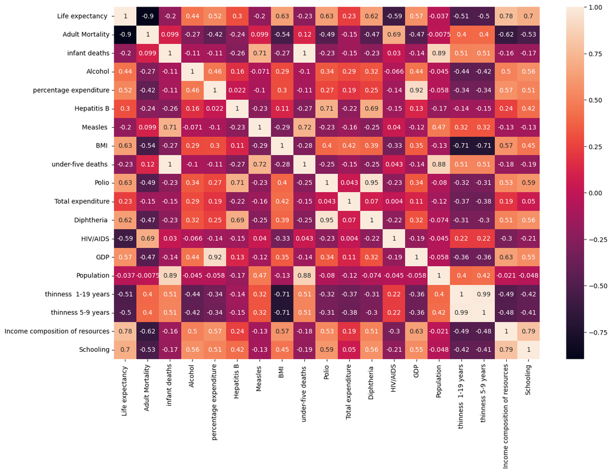

```python
"""Lets start with a heatmap to choose the features for X.
We want to avoid overfitting"""
plt.figure(figsize=(15,10))
sns.heatmap(df.corr(), annot=True)
plt.show()
```

In a heatmap, the correlation value is linear. However, I have to watch out for Multicollinearity. So I won't be choosing features simply based on highest correlation (nearest to -1 or 1) to Life expectancy, but also with low correlation with each other. The features I choose are: Adult Mortality, Income Composition of Resources, Alcohol, BMI, Polio. I will only be using a number of features to avoid overfitting the model

```python
# linear regression class, which consists of functions.
class LinearRegression:

    def __init__(self, lr=0.01, n_iters=1000):
        """
        - initialization function
        - lr: learning rate for gradient descent
        - n_iters: number of iterations for gradient descent
        """
        self.lr = lr
        self.n_iters = n_iters
        self.weights = None  # coefficients for features
        self.bias = None     # intercept term

    def fit(self, X, y):
        """
        - Used for training the linear regression model using gradient descent.
        - X: Features (numpy array). initialized already
        - y: Target variable (numpy array). initialized already
        """
        # create an array as big as X
        n_samples, n_features = X.shape

        # initialize weights and bias to 0s
        self.weights = np.zeros(n_features)
        self.bias = 0

        # gradient Descent iterations
        for _ in range(self.n_iters):
            # predicted values
            y_pred = np.dot(X, self.weights) + self.bias

            # calculate gradients
            dw = (1/n_samples) * np.dot(X.T, (y_pred - y))
            db = (1/n_samples) * np.sum(y_pred - y)

            # update weights and bias
            self.weights = self.weights - self.lr * dw
            self.bias = self.bias - self.lr * db

    def predict(self, X):
        """
        This function makes predictions using the trained linear regression model.
        - X: Feature matrix for prediction (numpy array).

        It should return
        - y_pred: Predicted values.
        """
        y_pred = np.dot(X, self.weights) + self.bias
        return y_pred

    def kfoldCV_r2(self, X, y, k=5):
        """
        Perform k-fold cross-validation for the linear regression model and calculate R-squared.

        Parameters:
        - X: Features (numpy array).
        - y: Target variable (numpy array).
        - k: Number of folds for cross-validation.

        Returns:
        - avg_r2: Average R-squared score across folds.
        """
        n_samples = len(X)
        fold_size = n_samples // k

        r2_values = []

        for i in range(k):
            start_idx = i * fold_size
            end_idx = (i + 1) * fold_size if i < k - 1 else n_samples

            # split data into training and validation sets
            X_train = np.concatenate([X[:start_idx], X[end_idx:]])
            y_train = np.concatenate([y[:start_idx], y[end_idx:]])
            X_val = X[start_idx:end_idx]
            y_val = y[start_idx:end_idx]

            # feature scaling (assuming you want to scale within each fold)
            scaler = StandardScaler()
            X_train = scaler.fit_transform(X_train)
            X_val = scaler.transform(X_val)

            # train the model on the training data
            self.fit(X_train, y_train)

            # Make predictions on the validation set
            predictions = self.predict(X_val)

            # Calculate R-squared for this fold
            ss_t = np.sum((y_val - np.mean(y_val)) ** 2)
            ss_r = np.sum((y_val - predictions) ** 2)
            r2 = 1 - (ss_r / ss_t)
            r2_values.append(r2)

        avg_r2 = np.mean(r2_values)
        return avg_r2
```

```
RMSE: 2.993207674003404
R2 Score/Model score: 0.8956430957006138
Average R-squared across folds: 0.9003584214931429
```

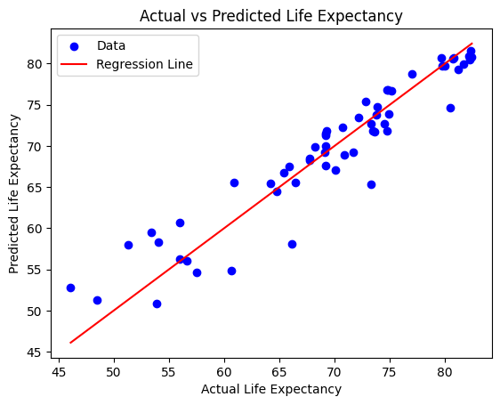

```python
import numpy as np
from sklearn.model_selection import train_test_split
from sklearn.preprocessing import StandardScaler
from sklearn import datasets
import matplotlib.pyplot as plt

# # Assuming X and y are your feature matrix and target variable
X_columns = ['Income composition of resources', 'Alcohol', 'Polio', 'Adult Mortality', ' BMI ']
X = df[X_columns]
y = df['Life expectancy ']

# Split data into training and testing sets
X_train, X_test, y_train, y_test = train_test_split(X, y, test_size=0.3, random_state=42)

# Feature scaling
# Normalize features using StandardScaler
scaler = StandardScaler()
X_train = scaler.fit_transform(X_train)
X_test = scaler.transform(X_test)

import scipy
Linear_model = LinearRegression(lr=0.01)

# train the model on the training data
Linear_model.fit(X_train, y_train)

# make predictions on the test set
predictions = Linear_model.predict(X_test)

# mean Squared Error (MSE) calculation for model evaluation
def mse(y_test, predictions):
    return ((y_test - predictions) ** 2).mean()


mse_value = mse(y_test, predictions)
print('RMSE:', mse_value ** 0.5)

# Calculate R-squared value manually
ss_t = np.sum((y_test - np.mean(y_test)) ** 2)
ss_r = np.sum((y_test - predictions) ** 2)
r2 = 1 - (ss_r / ss_t)

print('R2 Score/Model score:', r2)

# cross validation
avg_r2 = Linear_model.kfoldCV_r2(X, y, k=5)
print('Average R-squared across folds:', avg_r2)

# create a scatter plot for the test and predictions
plt.scatter(y_test, predictions, color='blue', label='Data')
plt.plot([min(y_test), max(y_test)], [min(y_test), max(y_test)], color='red', label='Regression Line')

# add labels and a legend
plt.xlabel('Actual Life Expectancy')
plt.ylabel('Predicted Life Expectancy')
plt.title('Actual vs Predicted Life Expectancy')
plt.legend()

# Show the plot
plt.show()
```

## Part 1.2 Polynomial Regression

This part will be about Polynomial Regression. In this part, I will use sklearn. With polynomial regression, we can capture more complex relationships between features. I will be experimenting with the same features as the linear regression model and other features as well, to explore other shapes during the visualization part.

## Part 1.2.1

I will be using the same feature columns as the linear regression model

```python
from sklearn.model_selection import train_test_split, KFold, cross_val_score
from sklearn.linear_model import LinearRegression
from sklearn.preprocessing import PolynomialFeatures
from sklearn.metrics import mean_squared_error, r2_score
from sklearn.pipeline import make_pipeline

# set target and features
target_column = 'Life expectancy '
feature_columns = ['Income composition of resources', 'Alcohol', 'Polio', 'Adult Mortality', ' BMI ']
X = df[feature_columns]
y = df[target_column]

# split data into train and test
X_train, X_test, y_train, y_test = train_test_split(X, y, test_size=0.3, random_state=42)

# normalize data
scaler = StandardScaler()
scaler.fit(X_train)
X_train = scaler.transform(X_train)
X_test = scaler.transform(X_test)

# assign polynomial degree
Polynomial_model = make_pipeline(PolynomialFeatures(degree=2, include_bias = False), LinearRegression())

# train model
Polynomial_model.fit(X_train, y_train)

# make predictions on the test set
predictions = Polynomial_model.predict(X_test)

# model evaluation
mse = mean_squared_error(y_test, predictions)
r2 = r2_score(y_test, predictions)

print('RMSE:', mse**0.5)
print(f'R2/Model Score: {r2:.2f}')

# perform cross-validation
num_folds = 5
kf = KFold(n_splits=num_folds, shuffle=True, random_state=42)

# Perform cross-validation
cross_val_results = cross_val_score(Polynomial_model, X, y, cv=kf, scoring='r2')

# Display the cross-validated results
print(f'Cross-validated R2 Score: {cross_val_results.mean()}')
```

```
RMSE: 3.0238954572521344
R2/Model Score: 0.89
Cross-validated R2 Score: 0.9008152701635851
```

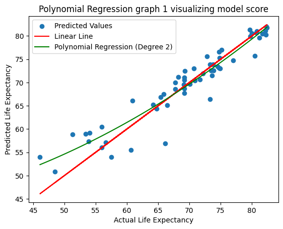

```python
# visualize the polynomial regression
plt.scatter(y_test, predictions, label='Predicted Values')
plt.plot(y_test, y_test, color='red', label='Linear Line')

# convert y_test to a numpy array and reshape it
y_test_np = y_test.values.reshape(-1, 1)

# fit a polynomial regression line
degree = 2
poly_features = PolynomialFeatures(degree=degree, include_bias = False)
X_poly = poly_features.fit_transform(y_test_np)
poly_model = LinearRegression()
poly_model.fit(X_poly, predictions)
# visualize the polynomial regression line
x_values = np.linspace(min(y_test), max(y_test), 100).reshape(-1, 1)
x_poly_values = poly_features.transform(x_values)
y_poly_pred = poly_model.predict(x_poly_values)
plt.plot(x_values, y_poly_pred, color='green', label=f'Polynomial Regression (Degree {degree})')

plt.xlabel("Actual Life Expectancy")
plt.ylabel("Predicted Life Expectancy")
plt.title("Polynomial Regression graph 1 visualizing model score")
plt.legend()
plt.show()
```

## Part 1.2.2

```python
target_column = 'Life expectancy '

# choose new features column to purposely drive down the score
feature_columns = ['Income composition of resources', 'Measles ', 'Polio','Hepatitis B' , 'Total expenditure']
X = df[feature_columns]
y = df[target_column]

# split data into train and test
X_train, X_test, y_train, y_test = train_test_split(X, y, test_size=0.3, random_state=42)

# normalize data
scaler = StandardScaler()
scaler.fit(X_train)
X_train = scaler.transform(X_train)
X_test = scaler.transform(X_test)


# assign polynomial degree
degree = 2
Polynomial_model = make_pipeline(PolynomialFeatures(degree), LinearRegression())

# train model
Polynomial_model.fit(X_train, y_train)

# make predictions on the test set
predictions = Polynomial_model.predict(X_test)

# model evaluation
mse = mean_squared_error(y_test, predictions)
r2 = r2_score(y_test, predictions)

print('RMSE:', mse**0.5)
print(f'R2/Model Score: {r2:.2f}')

# perform cross-validation
num_folds = 5
kf = KFold(n_splits=num_folds, shuffle=True, random_state=42)

# Perform cross-validation
cross_val_results = cross_val_score(Polynomial_model, X, y, cv=kf, scoring='r2')

# Display the cross-validated results
print(f'Cross-validated R2 Score: {cross_val_results.mean()}')
```

```
RMSE: 5.8440607023429205
R2/Model Score: 0.60
Cross-validated R2 Score: 0.14689677350321348
```

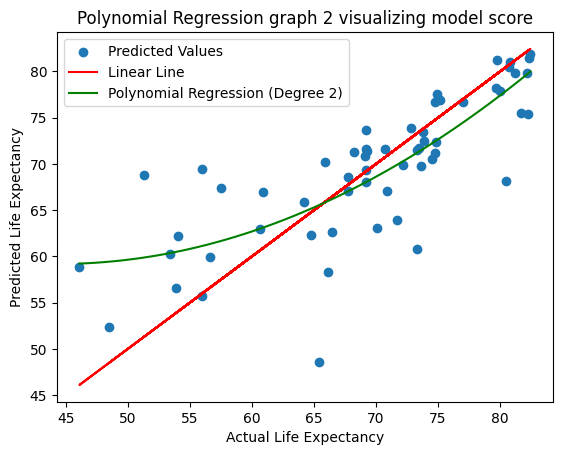

```python
# visualize the polynomial regressoin
plt.scatter(y_test, predictions, label='Predicted Values')
plt.plot(y_test, y_test, color='red', label='Linear Line')

# convert y_test to a numpy array and reshape it
y_test_np = y_test.values.reshape(-1, 1)

# fit a polynomial regression line
degree = 2
poly_features = PolynomialFeatures(degree=degree)
X_poly = poly_features.fit_transform(y_test_np)
poly_model = LinearRegression()
poly_model.fit(X_poly, predictions)

# visualize the polynomial regression line
x_values = np.linspace(min(y_test), max(y_test), 100).reshape(-1, 1)
x_poly_values = poly_features.transform(x_values)
y_poly_pred = poly_model.predict(x_poly_values)
plt.plot(x_values, y_poly_pred, color='green', label=f'Polynomial Regression (Degree {degree})')

plt.xlabel("Actual Life Expectancy")
plt.ylabel("Predicted Life Expectancy")
plt.title("Polynomial Regression graph 2 visualizing model score")
plt.legend()
plt.show()
```

In part 1, we learned that linear regression and polynomial regression are similar in what they provide to a dataset. We can see on part 1.2.1 (polynomial regression) that the results are very similar to the first linear regression model that I built in 1.1. This is because the features I chose are the same and there really isn't a point to be curving the linear line. However, when I chose different features, specifically those with low correlation values to life expectancy, the polynomial features can be noticed. The model test score goes down and the data points become more complex. The relationship between x and y are no longer linear. Polynomial regression is good for these complex datas.

## Part 2:

Some aspects that can be compared on these 2 are:

- Simplicity/Complexity
- Implementation
- Interpretability and Data presentation

To start this part, I will do some data modification

```python
"""change the status to 0 and 1
0 == Developing
1 == Developed
"""
df['Status'] = [0 if status == 'Developing' else 1 for status in df['Status']]
```

```python
df.head(10)
```

|  | Country | Status | Life expectancy | Adult Mortality | infant deaths | Alcohol | percentage expenditure | Hepatitis B | Measles | BMI | under-five deaths | Polio | Total expenditure | Diphtheria | HIV/AIDS | GDP | Population | thinness 1-19 years | thinness 5-9 years | Income composition of resources | Schooling |
| --- | --- | --- | --- | --- | --- | --- | --- | --- | --- | --- | --- | --- | --- | --- | --- | --- | --- | --- | --- | --- | --- |
| 0 | Afghanistan | 0 | 58.19 | 269.06 | 78.25 | 0.01 | 34.96 | 64.56 | 2362.25 | 15.52 | 107.56 | 48.38 | 8.25 | 52.31 | 0.10 | 340.02 | 9972259.81 | 16.58 | 15.58 | 0.42 | 8.21 |
| 1 | Albania | 0 | 75.16 | 45.06 | 0.69 | 4.85 | 193.26 | 98.00 | 53.38 | 49.07 | 0.94 | 98.12 | 5.95 | 98.06 | 0.10 | 2119.73 | 696911.62 | 1.62 | 1.70 | 0.71 | 12.14 |
| 2 | Algeria | 0 | 73.62 | 108.19 | 20.31 | 0.67 | 236.19 | 78.74 | 1943.88 | 48.74 | 23.50 | 91.75 | 4.69 | 91.88 | 0.10 | 2847.85 | 21649827.44 | 6.09 | 5.98 | 0.69 | 12.71 |
| 3 | Angola | 0 | 49.02 | 328.56 | 83.75 | 5.67 | 102.10 | 74.91 | 3561.31 | 18.02 | 132.62 | 46.12 | 4.05 | 47.69 | 2.37 | 1975.14 | 10147099.19 | 6.19 | 6.67 | 0.46 | 8.04 |
| 4 | Antigua and Barbuda | 0 | 75.06 | 127.50 | 0.00 | 7.74 | 1001.59 | 97.18 | 0.00 | 38.42 | 0.00 | 96.94 | 4.86 | 98.31 | 0.12 | 9759.31 | 12753375.12 | 3.42 | 3.38 | 0.49 | 8.84 |
| 5 | Argentina | 0 | 75.16 | 106.00 | 10.12 | 7.76 | 773.04 | 81.24 | 2.00 | 54.98 | 11.38 | 93.38 | 6.85 | 92.38 | 0.10 | 6998.58 | 20121204.50 | 1.08 | 0.95 | 0.79 | 16.51 |
| 6 | Armenia | 0 | 73.40 | 117.38 | 1.00 | 3.76 | 131.01 | 87.56 | 274.25 | 44.71 | 1.00 | 89.12 | 4.93 | 87.38 | 0.10 | 1999.99 | 1015164.62 | 2.04 | 2.11 | 0.70 | 11.79 |
| 7 | Australia | 1 | 81.81 | 63.19 | 1.00 | 9.81 | 5332.23 | 92.62 | 103.94 | 55.86 | 1.38 | 86.75 | 8.66 | 86.88 | 0.10 | 34637.57 | 4587009.88 | 0.67 | 0.62 | 0.92 | 20.04 |
| 8 | Austria | 1 | 81.48 | 65.75 | 0.00 | 11.76 | 4928.44 | 81.06 | 77.25 | 48.29 | 0.00 | 86.00 | 4.79 | 86.75 | 0.10 | 33827.48 | 6474879.88 | 1.73 | 1.94 | 0.86 | 15.39 |
| 9 | Azerbaijan | 0 | 70.73 | 115.19 | 6.06 | 1.22 | 131.15 | 61.93 | 598.19 | 43.84 | 7.19 | 75.81 | 5.70 | 82.31 | 0.10 | 3302.95 | 2157370.50 | 2.90 | 2.94 | 0.70 | 11.35 |

```python
# process outliers for better results
from scipy.stats import mstats

# filter the dataset where status is equal to 0
df_status_0 = df[df['Status'] == 0]

# winsorize
df_status_0['Life expectancy '] = mstats.winsorize(df_status_0['Life expectancy '], limits=[0.05, 0.2])

# update the original dataset
df.loc[df['Status'] == 0, 'Life expectancy '] = df_status_0['Life expectancy ']
```

### Part 2.1 Logistic Regression

I will be using Logistic Regression on the Status columns as the target and Life expectancy column as the feature. The life expectancy of the country is used to predict its development status.

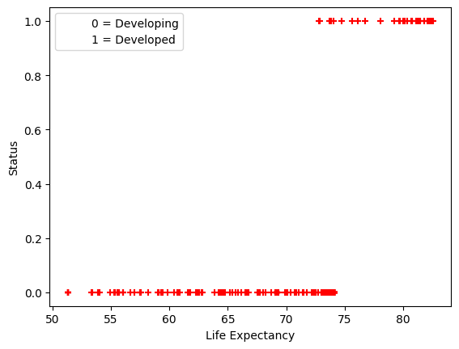

```python
# First visualization
plt.scatter(df['Life expectancy '], df['Status'], marker = '+', color='red')
plt.xlabel('Life Expectancy')
plt.ylabel('Status')

legend_labels = {0: '0 = Developing', 1: '1 = Developed'}
# Create a custom legend with the desired labels
custom_legend = [plt.Line2D([0], [0], color='w', label=legend_labels[label]) for label in legend_labels]

# Add the legend to the plot
plt.legend(handles=custom_legend)

plt.show()
```

```
Accuracy: 0.9487179487179487
Confusion Matrix:
 [[32  0]
 [ 2  5]]
Classification Report:
               precision    recall  f1-score   support

           0       0.94      1.00      0.97        32
           1       1.00      0.71      0.83         7

    accuracy                           0.95        39
   macro avg       0.97      0.86      0.90        39
weighted avg       0.95      0.95      0.95        39

Cross-validated Score: 0.963697705802969
```

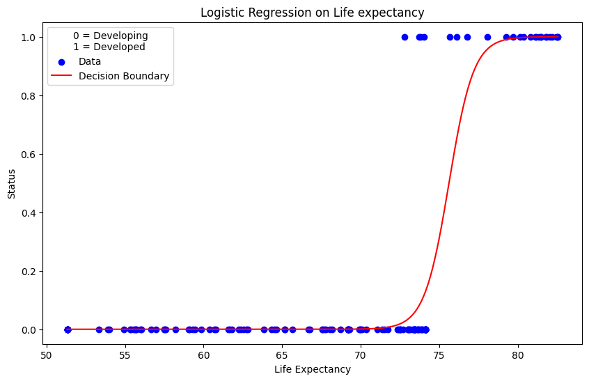

```python
from sklearn.linear_model import LogisticRegression
from sklearn.metrics import confusion_matrix, classification_report

# initialize x and y
X = df['Life expectancy '].values.reshape(-1, 1)  # reshape to a 2D array
y = df['Status']

X_train, X_test, y_train, y_test = train_test_split(X, y, test_size =0.2, random_state = 42)

# use logistic regression model
logistic_model = LogisticRegression()
logistic_model.fit(X_train, y_train)
y_pred = logistic_model.predict(X_test)

# print results
accuracy = logistic_model.score(X_test, y_test)
print("Accuracy:", accuracy)


cnf_matrix = confusion_matrix(y_test, y_pred)
class_report = classification_report(y_test, y_pred)

"""Confusion matrix format:
[[TN FP]
 [FN TP]]
"""

print("Confusion Matrix:\n", cnf_matrix)
print("Classification Report:\n", class_report)

# do cross validation
num_folds = 5
kf = KFold(n_splits=num_folds, shuffle=True, random_state=42)

# Perform cross-validation
cross_val_results = cross_val_score(logistic_model, X, y, cv=kf, scoring='accuracy')

# Display the cross-validated results
print(f'Cross-validated Score: {cross_val_results.mean()}')


# plot line
x_values = np.linspace(min(X_train), max(X_train), 1000).reshape(-1, 1)
y_prob = logistic_model.predict_proba(x_values)[:, 1]

plt.figure(figsize=(10, 6))
plt.scatter(X_train, y_train, color='blue', label='Data')
plt.plot(x_values, y_prob, color='red', label='Decision Boundary')

legend_text = '0 = Developing\n1 = Developed'


plt.title('Logistic Regression on Life expectancy')
plt.xlabel('Life Expectancy')
plt.ylabel('Status')
plt.legend(title = legend_text)
plt.show()
```

### Part 2.2 Decision Tree

I will be using Decision Tree on the Status columns as the target and Life expectancy column as the feature. The life expectancy of the country is used to predict its development status, similarly to the logistic regression model.

```
Accuracy: 0.9743589743589743
Confusion Matrix:
 [[32  0]
 [ 1  6]]
Classification Report:
               precision    recall  f1-score   support

           0       0.97      1.00      0.98        32
           1       1.00      0.86      0.92         7

    accuracy                           0.97        39
   macro avg       0.98      0.93      0.95        39
weighted avg       0.98      0.97      0.97        39

Cross-validated Score: 0.9635627530364372
```

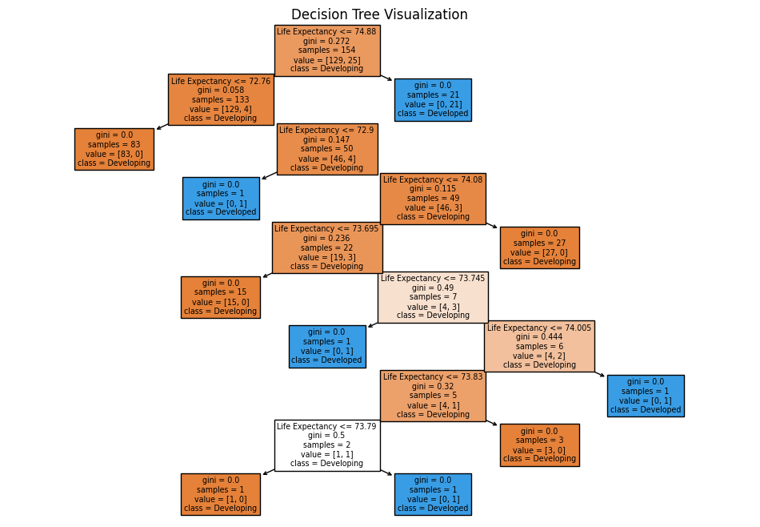

```python
from sklearn.tree import DecisionTreeClassifier, plot_tree
from sklearn.metrics import accuracy_score, confusion_matrix, classification_report

# initialize x and y
X = df['Life expectancy '].values.reshape(-1, 1)  # reshape to a 2D array
y = df['Status']

# split the data into training and testing sets
X_train, X_test, y_train, y_test = train_test_split(X, y, test_size=0.2, random_state=42)

# use decision tree model
tree_model = DecisionTreeClassifier()
tree_model.fit(X_train, y_train)
y_pred = tree_model.predict(X_test)

# evaluate the model
accuracy = accuracy_score(y_test, y_pred)
cnf_matrix = confusion_matrix(y_test, y_pred)
class_report = classification_report(y_test, y_pred)


"""Confusion matrix format:
[[TN FP]
 [FN TP]]
"""

# print results
print("Accuracy:", accuracy)
print("Confusion Matrix:\n", cnf_matrix)
print("Classification Report:\n", class_report)

# do cross validation
num_folds = 5
kf = KFold(n_splits=num_folds, shuffle=True, random_state=42)

# Perform cross-validation
cross_val_results = cross_val_score(tree_model, X, y, cv=kf, scoring='accuracy')

# Display the cross-validated results
print(f'Cross-validated Score: {cross_val_results.mean()}')


# Plot the decision tree
plt.figure(figsize=(12, 8))
plot_tree(tree_model, filled=True, feature_names=['Life Expectancy'], class_names=['Developing', 'Developed'])
plt.title('Decision Tree Visualization')
plt.show()
```

## Conclusion

Logistic Regression, despite having regression in its name is actually a classification algorithm. It is best used for classifying binary features (0 or 1, True or False, etc.). In this experiment, Life expectancy (X) is used to predict whether a country is developed or developing (y). It uses a graph with a Decision Boundary line to do this. I also implemented the same concept to a decision tree model. It scores well, similar to the Logistic Regression model. However, the presentation of the results are totally different. The decision tree is best represented as a tree, which shows the decision making of the algorithm step-by-step.

In conclusion, there are many Machine Learning algorithms because there are many types of data and datasets which require different methods in order for us to understand them. Some models are able to shine according to the dataset they are implemented with, while some models don’t work well for certain datasets.